# Mise en oeuvre d’une ACP sur des Eaux

## 2.4. Classification non supervisée de type k-means

Pour approfondir notre analyse, on peut choisir de classer nos individus par catégories, par classes. Ainsi, on pourrait voir apparaître différents types d’eau dans nos données.

Plusieurs méthodes s’offrent à nous. Cependant, nous n’avons pas vraiment de types d’eaux prédéfinis, ni de données d’entraînement sur lesquelles s’appuyer : le choix d’une méthode de partitionnement non supervisée semble donc raisonnable.

La fonction `kmeans(data, k)` déjà implémentée a été conçue à dessein. À partir des données d’entrée et d’un nombre de classes k, l’algorithme regroupe les individus selon leurs distances relatives, jusqu’à trouver les distances minimales.

Même si l’algorithme est déjà implémenté, il nous faut quand même trouver un k optimal. En effet, ce choix est primordial : si on prend un k trop petit, le risque est de se retrouver avec des classes peu représentatives, assez arbitraires; si le k choisi est trop grand, on peut obtenir des classes qui ne s’appliquent qu’à notre jeu de données, ou alors avoir beaucoup de classes mais avec très peu d’individus.

Quand on applique l’algorithme, il nous renvoie la somme des carrées des distances entre les individus et le centre des classes. Une part plus petite par rapport à la somme de toutes les distances étant meilleure, on peut dessiner le graphique de cette part, en fonction de k. En observant les décrochages de la courbe, on peut alors décider d’un k satisfaisant.

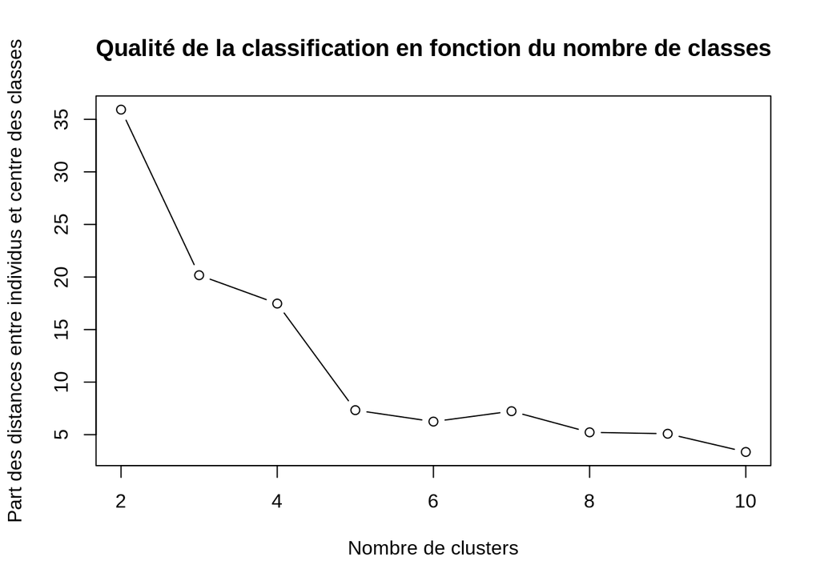

Figure 13

Il faut aussi préciser que la fonction kmeans incorpore de l’aléatoire. On préfère donc fixer la graine de l’aléatoire afin d’avoir toujours les mêmes résultats.

Le graphique montre qu’à k=5, la qualité de représentation ne progresse plus beaucoup; 5 semble donc être un choix raisonnable. Une fois executé, l’algorithme nous revoie un tableau des individus classés. On peut donc, pour se donner une idée, appliquer ce tableau à une représentation en deux ou trois dimensions issue de l’ACP.

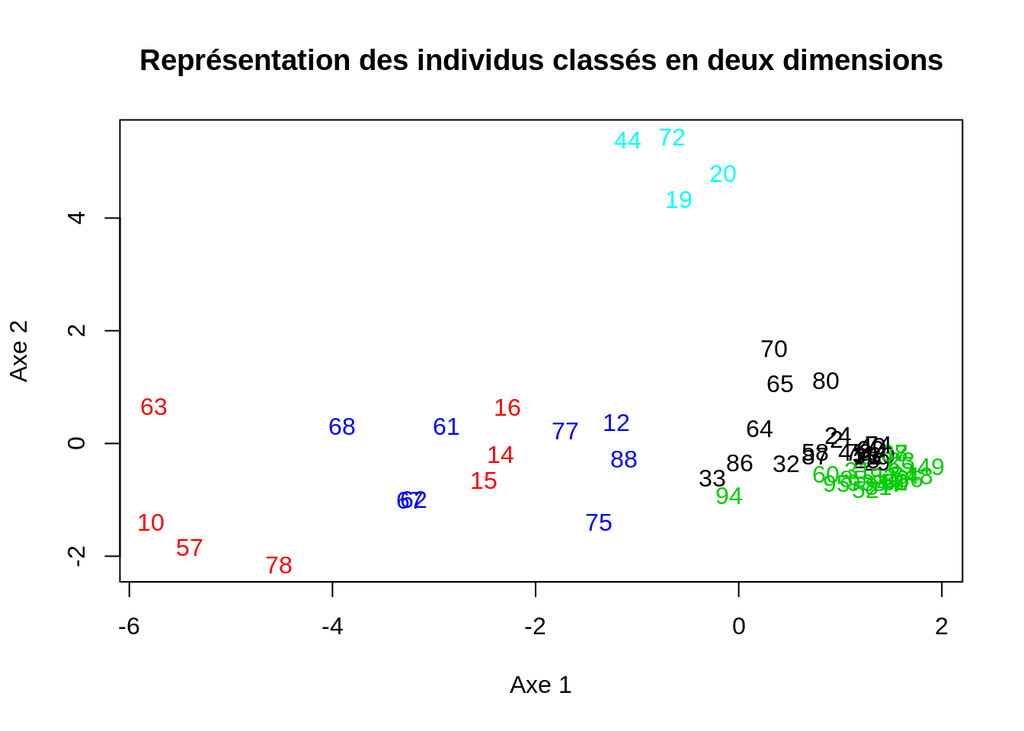

Figure 14

## Code source

ACP “automatique”

```
# Importation du jeu de données
waters <- read.table("/home/sol/Téléchargements/Eaux2018 FM.txt", header=TRUE, sep="\t")
attach(waters)

# 1. Analyse univariée et bivariée
## 1.1. Etude du jeu de données
head(waters)
dim(waters)  # 95 lignes, 12 variables
names(waters)
lapply(waters, class) # 3 variables qualitatives ; 9 variables quantitatives

active.waters <- waters[waters$Pays %in% "France",]
nrow(active.waters) # 84 obs. actives
supp.waters <- waters[waters$Pays %in% "Maroc",]
nrow(supp.waters) # 11 obs. supplémentaires

num.variables <- waters[sapply(waters, is.numeric)] # variables quantitatives
cat.variables <- waters[sapply(waters, is.factor)] # variables qualitatives

## 1.2. Analyse exploratoire des données
### 1.2.1. Recherche des données manquantes/corrompues
colSums(is.na(waters))

### 1.2.2. Analyse unidimensionnelle : variables qualitatives
still.waters <- subset(waters, waters$Nature=='plat', select=Ca:PH)
gaz.waters <- subset(waters[sapply(waters, is.numeric)], waters$Nature=='gaz')

summary(still.waters)
summary(gaz.waters)
colMeans(still.waters, na.rm=TRUE)
colMeans(gaz.waters, na.rm=TRUE)
table(waters$Nature, waters$Pays) # Table de contingence des eaux (par nature et pays)
par(mfrow=c(1,1))
mosaicplot(~waters$Pays+waters$Nature, data=waters, main="Répartition des eaux par Nature et Pays", color=TRUE)

### 1.2.3. Analyse unidimensionnelle : variables quantitatives
summary(num.variables)
boxplot(num.variables, main="Boîtes à moustaches des variables quantitatives du jeu de données")

# Etude de la variable PH
summary(waters$PH)
par(mfrow=c(1,2))
boxplot(waters$PH, main="Boîte à moustache de la variable PH")
hist(waters$PH, prob=TRUE, main="Histogramme et densité de probabilité du PH", xlab="PH")
curve(dnorm(x, mean=mean(waters$PH, na.rm=TRUE), sd=sd(waters$PH, na.rm=TRUE)), add=TRUE, col="red")

# Etude de la variable NO3
summary(waters$NO3)
par(mfrow=c(1,2))
boxplot(waters$NO3, main="Boîte à moustache de la variable NO3")
hist(waters$NO3, prob=TRUE, main="Histogramme et densité de probabilité du NO3", xlab="NO3")
curve(dnorm(x, mean=mean(waters$NO3, na.rm=TRUE), sd=sd(waters$NO3, na.rm=TRUE)), add=TRUE, col="red")

# Etude des variables Cl, K, SO4, et HCO3
par(mfrow=c(2,2))
hist(waters$Cl, prob=TRUE, main="Histogramme et densité de probabilité du Cl", xlab="Cl")
curve(dnorm(x, mean=mean(waters$Cl, na.rm=TRUE), sd=sd(waters$Cl, na.rm=TRUE)), add=TRUE, col="red")
hist(waters$K, prob=TRUE, main="Histogramme et densité de probabilité du K", xlab="K")
curve(dnorm(x, mean=mean(waters$K, na.rm=TRUE), sd=sd(waters$K, na.rm=TRUE)), add=TRUE, col="red")
hist(waters$SO4, prob=TRUE, main="Histogramme et densité de probabilité du SO4", xlab="SO4")
curve(dnorm(x, mean=mean(waters$SO4, na.rm=TRUE), sd=sd(waters$SO4, na.rm=TRUE)), add=TRUE, col="red")
hist(waters$HCO3, prob=TRUE, main="Histogramme et densité de probabilité du HCO3", xlab="HCO3")
curve(dnorm(x, mean=mean(waters$HCO3, na.rm=TRUE), sd=sd(waters$HCO3, na.rm=TRUE)), add=TRUE, col="red")

### 1.2.4. Recherche des valeurs extrêmes/outliers
boxplot.stats(waters$SO4)$out
which(waters$SO4 %in% boxplot.stats(waters$SO4)$out)
boxplot.stats(waters$K)$out
which(waters$K %in% boxplot.stats(waters$K)$out)
boxplot.stats(waters$Na)$out
which(waters$Na %in% boxplot.stats(waters$Na)$out)
boxplot.stats(waters$Cl)$out
which(waters$Cl %in% boxplot.stats(waters$Cl)$out)

### 1.2.5. Analyse bidimensionnelle
plot(num.variables, main="Nuage de points croisant deux à deux les variables du jeu de données")
round(cor(num.variables, use="complete.obs"),3)

# 2. Analyse multivariée
## 2.1. ACP sur le premier jeu de données

complete.waters <- na.omit(waters)
dim(complete.waters)
active.waters <- complete.waters[complete.waters$Pays %in% "France",]
acp.variables <- active.waters[sapply(active.waters, is.numeric)] # On ne conserve que les obs. actives

# [ACP via la fonction "dudi.pca"]
library(ade4)
auto.acp <- dudi.pca(df = acp.variables, center = TRUE, scale = TRUE, scannf = FALSE, nf = 9)

### 2.1.1. Sélection des axes et plans retenus
round(auto.acp$eig,3)
round(cumsum(100*auto.acp$eig/sum(auto.acp$eig)), 3)

### 2.1.2. Projection des variables et observations dans un plan donné
# Analyse des variables
var.inertie <- inertia.dudi(auto.acp, col.inertia=TRUE)
round(auto.acp$co,3)
F <- round(auto.acp$li,2) # Matrice des composantes principales
var.ctr <- var.inertie$col.abs/100 # (Contribution des variables en %)
var.qlt <- var.inertie$col.re/100 # (Qualité des variables en %)

par(mfrow=c(1,1))
s.corcircle(auto.acp$co, xax=1, yax=2) ; mtext("Cercle des corrélations dans le plan 1-2")
s.corcircle(auto.acp$co, xax=1, yax=3) ; mtext("Cercle des corrélations dans le plan 1-3")
s.corcircle(auto.acp$co, xax=2, yax=3) ; mtext("Cercle des corrélations dans le plan 2-3")

# Analyse des observations
round(auto.acp$l1, 3)
obs.inertie <- inertia.dudi(auto.acp, row.inertia=TRUE)
obs.ctr <- obs.inertie$row.abs/100 # (Contribution des observations en %)
obs.qlt <- obs.inertie$row.re/100 # (Qualité des observations en %)

abs(round(obs.qlt,4)[1]+round(obs.qlt,4)[2])
abs(round(obs.qlt,4)[1])+abs(round(obs.qlt,4)[3])
abs(round(obs.qlt,4)[2])+abs(round(obs.qlt,4)[3])

s.label(auto.acp$li,xax=1,yax=2, sub = "Projection des observations dans le plan 1-2")
s.label(auto.acp$li,xax=1,yax=3, sub = "Projection des observations dans le plan 1-3")
s.label(auto.acp$li,xax=2,yax=3, sub = "Projection des observations dans le plan 2-3")

### 2.1.3. Analyse des observations supplémentaires
supp.waters
med.PH <- median(waters$PH, na.rm =TRUE)
supp.waters[5,11] <- med.PH # On substitue les valeurs de PH manquantes par la médiane du PH (7)
supp.waters[6,11] <- med.PH
supp.waters[7,11] <- med.PH
supp.waters[8,11] <- med.PH

new.supp.waters <- na.omit(supp.waters)

cl1 <- auto.acp$li[,1]
cl2 <- auto.acp$li[,2]
cl3 <- auto.acp$li[,3]
ligsup <- suprow(auto.acp,new.supp.waters[3:11])
ligsup$lisup # Coordonnées des individus supplémentaires
csup1 <- ligsup$lisup[,1]
csup2 <- ligsup$lisup[,2]
csup3 <- ligsup$lisup[,3]

# Graphe des observations supplémentaires
plot(cl1, cl2, type="n", main="Projection des individus supplémentaires dans le plan 1-2", xlim=c(-2,2),ylim=c(-1,1))
abline(h=0,v=0)
text(csup1, csup2, row.names(ligsup$lisup), col="red", cex=1.2)

# Graphe des observations actives et supplémentaires - plan 1-2
plot(cl1, cl2, type="n", main="Projection des individus actifs (noirs) et supplémentaires (rouges) dans le plan 1-2", xlim=c(-2,2))
abline(h=0,v=0)
text(cl1, cl2, row.names(auto.acp$li))
text(csup1, csup2, row.names(ligsup$lisup), col="red", cex=1.2)

# Graphe des observations actives et supplémentaires - plan 1-3
plot(cl1, cl3, type="n", main="Projection des individus actifs (noirs) et supplémentaires (rouges) dans le plan 1-3", xlim=c(-2,2))
abline(h=0,v=0)
text(cl1, cl3, row.names(auto.acp$li))
text(csup1, csup3, row.names(ligsup$lisup), col="red", cex=1.2)

# Graphe des observations actives et supplémentaires - plan 2-3
plot(cl2, cl3, type="n", main="Projection des individus actifs (noirs) et supplémentaires (rouges) dans le plan 2-3", xlim=c(-2,2))
abline(h=0,v=0)
text(cl2, cl3, row.names(auto.acp$li))
text(csup2, csup3, row.names(ligsup$lisup), col="red", cex=1.2)

## 2.2. ACP sur le deuxième jeu de données
library(DMwR)
new.waters <- knnImputation(waters, k=10, scale=T, meth="weighAvg", distData=NULL) # On fixe k à 10 voisins
new.active.waters <- new.waters[new.waters$Pays %in% "France",]

# 2.2.1. Sélection des axes et plans retenus
acp.variables <- new.active.waters[sapply(new.active.waters, is.numeric)] # On ne conserve que les obs. actives
new.auto.acp <- dudi.pca(df = acp.variables, center = TRUE, scale = TRUE, scannf = FALSE, nf = 9)
round(new.auto.acp$eig,3)
round(cumsum(100*new.auto.acp$eig/sum(new.auto.acp$eig)), 3)

# 2.2.2. Projection des variables et observations dans un plan donné
var.inertie <- inertia.dudi(new.auto.acp, col.inertia=TRUE)
round(new.auto.acp$co,3)
F <- round(new.auto.acp$li,2) # Matrice des composantes principales
var.ctr <- var.inertie$new.col.abs/100 # (Contribution des variables en %)
var.qlt <- var.inertie$new.col.re/100 # (Qualité des variables en %)

s.corcircle(new.auto.acp$co, xax=1, yax=2) ; mtext("Cercle des corrélations dans le plan 1-2")
s.corcircle(new.auto.acp$co, xax=1, yax=3) ; mtext("Cercle des corrélations dans le plan 1-3")
s.corcircle(new.auto.acp$co, xax=2, yax=3) ; mtext("Cercle des corrélations dans le plan 2-3")

# Analyse des observations
round(new.auto.acp$l1, 3)
new.obs.inertie <- inertia.dudi(new.auto.acp, row.inertia=TRUE)
new.obs.ctr <- new.obs.inertie$row.abs/100 # (Contribution des observations en %)
new.obs.qlt <- new.obs.inertie$row.re/100 # (Qualité des observations en %)

outliers <- sort(unique(which(is.na(active.waters), arr.ind = TRUE)[,1]))

round(new.obs.qlt[,1:3],3)

s.label(auto.acp$li,xax=1,yax=2, sub = "Projection des observations dans le plan 1-2")
s.label(auto.acp$li,xax=1,yax=3, sub = "Projection des observations dans le plan 1-3")
s.label(auto.acp$li,xax=2,yax=3, sub = "Projection des observations dans le plan 2-3")

# 2.3. ACP sur le troisième jeu de données
data_in = waters[waters$Pays %in% "France",]
active.waters = na.omit(data_in[sapply(data_in, is.numeric)])
num_outliers = unique(unlist(apply(active.waters, 2, function(x){which(x %in% boxplot.stats(x)$out)})))
outliers = active.waters[setdiff(c(1:nrow(active.waters)), num_outliers),]
without_outliers = active.waters[num_outliers,]

auto.acp = dudi.pca(df = without_outliers, scannf = FALSE, nf = 3)

# 2.3.1. Sélection des axes et plans retenus
round(auto.acp$eig,3)
round(cumsum(100*auto.acp$eig/sum(auto.acp$eig)), 3)

# 2.3.2. Projection des variables et observations dans un plan donné
# Analyse des variables
var.inertie <- inertia.dudi(auto.acp, col.inertia=TRUE)
round(auto.acp$co,3)
F <- round(auto.acp$li,2) # Matrice des composantes principales
var.ctr <- var.inertie$new.col.abs/100 # (Contribution des variables en %)
var.qlt <- var.inertie$new.col.re/100 # (Qualité des variables en %)

s.corcircle(new.auto.acp$co, xax=1, yax=2) ; mtext("Cercle des corrélations dans le plan 1-2")
s.corcircle(new.auto.acp$co, xax=1, yax=3) ; mtext("Cercle des corrélations dans le plan 1-3")
s.corcircle(new.auto.acp$co, xax=2, yax=3) ; mtext("Cercle des corrélations dans le plan 2-3")

# Analyse des observations
obs.inertie <- inertia.dudi(auto.acp, row.inertia=TRUE)
obs.ctr <- obs.inertie$row.abs/100
obs.qlt <- obs.inertie$row.re/100

s.label(auto.acp$li,xax=1,yax=2); mtext("Projection des observations dans le plan 1-2")
s.label(auto.acp$li,xax=1,yax=3); mtext("Projection des observations dans le plan 1-3")
s.label(auto.acp$li,xax=2,yax=3); mtext("Projection des observations dans le plan 2-3")

### 2.3.3. Analyse des observations supplémentaires
axe1 <- auto.acp$li[,1]
axe2 <- auto.acp$li[,2]
axe3 <- auto.acp$li[,3]
ligsup <- suprow(auto.acp, outliers)
acpcos2sup <- ligsup$lisup^2/apply(ligsup$lisup^2, 1, sum)
round(acpcos2sup[,1:3]*1000)
csup1 <- ligsup$lisup[,1]
csup2 <- ligsup$lisup[,2]

plot(axe1, axe2, type="n", main="Individus actifs et supplémentaires dans le plan 1-2", xlim=c(-2,2))
abline(h=0,v=0)
text(axe1, axe2, row.names(auto.acp$li))
text(csup1, csup2, row.names(ligsup$lisup), col="red", cex=1.2)

# Graphe des observations actives et supplémentaires - plan 1-3
csup3 <- ligsup$lisup[,3]
plot(axe1, axe3, type="n", main="Individus actifs et supplémentaires dans le plan 1-3", xlim=c(-2,2))
abline(h=0,v=0)
text(axe1, axe3, row.names(auto.acp$li))
text(csup1, csup3, row.names(ligsup$lisup), col="red", cex=1.2)

# Graphe des observations actives et supplémentaires - plan 2-3
plot(axe2, axe3, type="n", main="Individus actifs et supplémentaires dans le plan 2-3", xlim=c(-2,2))
abline(h=0,v=0)
text(axe2, axe3, row.names(auto.acp$li))
text(csup2, csup3, row.names(ligsup$lisup), col="red", cex=1.2)
```

ACP “manuelle”

```
library(plotrix)
library(ade4)

acpn = function(data_in, round_precision = 3){
  result = list()

  result$source = data_in
  #Filtre
  result$raw_data = na.omit(data_in[sapply(data_in, is.numeric)])
  result$matrix = as.matrix(result$raw_data, rownames.force = NA)
  num_row = nrow(result$raw_data)
  num_col = ncol(result$raw_data)

  #Moyenne
  result$mean = apply(result$matrix, 2, mean)
  result$meanmatrix = t(matrix( rep(x=result$mean, num_row), nrow = num_col, byrow = FALSE))

  #Centrage avec scale
  result$autocen = scale(result$matrix, center = TRUE, scale = FALSE)
  #Centrage/Reduction avec scale
  result$autocenred = scale(result$matrix, center = TRUE, scale = TRUE)

  #Centrage sans scale
  result$cen = result$matrix - result$meanmatrix

  #Variance/co-variance
  result$var = t(result$cen) %*% result$cen / (num_row - 1)

  #Centrage/Reduction sans scale
  result$stddev = diag(sapply(diag(as.matrix(result$var)), function(x){1/sqrt(x)}))
  result$cenred = result$cen %*% result$stddev

  #Correlation
  result$cor = t(result$cenred) %*% result$cenred / (num_row - 1)

  #Valeurs propres
  eigen_full = eigen(result$cor)
  result$eigen$values = eigen_full$values[eigen_full$values>1.0]
  result$eigen$vectors = eigen_full$vectors[,1:length(result$eigen$values)]

  #Composantes principales
  result$comp = result$cenred %*% result$eigen$vectors

  #Rapport de l'inertie
  result$inertiaratio = result$eigen$values / num_col

  #Inertie cumulée
  result$inertiasum = round(sum(result$inertiaratio),3)*100

  #Contribution relative des individus
  result$qlti = (result$comp)^2
  for (i in 1:nrow(result$qlti)) {
    for (k in 1:ncol(result$qlti)) {
      result$qlti[i,k] = result$qlti[i,k] / (sum(result$comp[i,]^2))
    }
  }
  result$qtli = round(result$qlti, round_precision)

  #Contribution absolue des individus
  result$ctri = (result$comp)^2
  for (i in 1:nrow(result$ctri)) {
    for (k in 1:ncol(result$ctri)) {
      result$ctri[i,k] = result$ctri[i,k] / (ncol(result$ctri)*result$eigen$values[k])
    }
  }
  result$ctri = round(result$ctri, round_precision)

  #Matrice des coordonnées de variables
  D = diag(sapply(as.matrix(result$eigen$values), sqrt))
  result$coords = result$eigen$vectors %*% D

  #Contribution relative des variables
  result$qltv = (result$coords)^2
  for (j in 1:nrow(result$qltv)) {
    for (k in 1:ncol(result$qltv)) {
      result$qltv[j,k] = result$qltv[j,k] / (sum(result$coords[j,]^2))
    }
  }
  result$qtlv = round(result$qltv, round_precision)

  #Contribution absolue des variables
  result$ctri = (result$comp)^2
  for (i in 1:nrow(result$ctri)) {
    for (k in 1:ncol(result$ctri)) {
      result$ctri[i,k] = result$ctri[i,k] / (ncol(result$ctri)*result$eigen$values[k])
    }
  }
  result$ctri = round(result$ctri, round_precision)

  #Cercle de corrélation
  apply(combn(1:length(result$eigen$values), 2), 2, function(combi){
    axis1 = result$coords[,combi[1]]
    axis2 = result$coords[,combi[2]]
    par(mfrow=c(1,1))
    plot(axis1, axis2, xlim=c(-1,1), ylim=c(-1,1), asp = 1, type = "n", xlab = sprintf("Axe %d",combi[1]), ylab = sprintf("Axe %d",combi[2]), main = sprintf("Cercle des corrélations dans le plan %d-%d", combi[1], combi[2]) )
    abline(h=0,v=0)
    draw.circle(x = 0, y = 0, radius = c(1,1))
    arrows(0, 0, axis1, axis2, length = 0.10, code = 2, col = gray(0.6))
    text(x=axis1, y=axis2, labels = colnames(result$raw_data), font=2)
  })

  #Retour
  return(result)
}

addIndiv = function(acp, indiv){
  return( t(scale(as.matrix(na.omit(indiv[sapply(indiv, is.numeric)]), rownames.force = NA), center = TRUE, scale = TRUE) %*% acp$eigen$vectors ))
}


waters <- read.table("./Eaux2018 FM.txt", header=TRUE, sep="\t")
active.waters <- waters[waters$Pays %in% "France",]
supp.waters <- waters[waters$Pays %in% "Maroc",]
acp_waters = acpn(active.waters)

supps = t(addIndiv(acp_waters, supp.waters))

water_type = c()
for(i in rownames(acp_waters$comp)){
  type = acp_waters$source$Nature[strtoi(i)]
  v = 0
  print(type)
  if(is.na(type)){}
  else if(type == "plat"){
    v=1
  }else if(type == "gaz"){
    v=2
  }
  water_type = c(water_type, v)
}

plot(acp_waters$comp[,1], acp_waters$comp[,2], xlab = "Axe 1", ylab = "Axe 2", col=water_type)
legend(x = "bottomright",legend=unique(water_type),col=1:length(water_type),pch=1)

#eaux_actives <- filter(eaux, Pays== "France")
dudi = dudi.pca(df = acp_waters$raw_data, scannf = FALSE, nf = 3)

acp_waters$matrix[setdiff(c(1:nrow(acp_waters$matrix)), unique(unlist(apply(acp_waters$matrix, 2, function(x){which(x %in% boxplot.stats(x)$out)})))),]
```

Classification non supervisée (K-Means)

```
waters <- read.table("./Eaux2018 FM.txt", header=TRUE, sep="\t")
data = na.omit(waters[sapply(waters, is.numeric)])
library(ade4)

set.seed(3)
classi = kmeans(data, 5)

values = sapply(2:10, function(k){
  curr = kmeans(data, k)
  curr$tot.withinss/curr$totss*100
})

plot(2:10,values, type="b", xlab="Nombre de clusters", ylab = "Variance expliquée")

acp = dudi.pca(data, scannf = FALSE, nf=3)

plot(acp$li[,1], acp$li[,2], xlab = "Axe 1", ylab = "Axe 2", type="n")
text(x=acp$li[,1], y=acp$li[,2], labels = row.names(acp$li), col=unname(classi$cluster))

library(RJSONIO)

out_l = list()
for (k in names(classi$cluster)) {
  out_l[[k]] = list("k"=classi$cluster[[k]], "nom"=toString(waters$Nom[strtoi(k)]))
}
write(toJSON(out_l), file="./map/classif.json")

library(rgl)
open3d()
plot3d(acp$li[,1], acp$li[,2], acp$li[,3], "Axe 1", "Axe 2", "Axe 3",col=unname(classi$cluster), type = "s", size=0.2)
text3d(acp$li[,1], acp$li[,2], acp$li[,3], texts=row.names(acp$li) ,adj = 0, col=unname(classi$cluster), family="serif", font=5, cex=1)
```